# PEC 3

Pablo Ursúa y Oliver Mazariegos

2023-01-12

# Enunciado

El objetivo de la PEC es elaborar un análisis estadístico en R de un caso práctico con da-tos de obtención propia (pertenecientes a un determinado ámbito), lo más ajustado a la realidad.

# 1) (1 punto) Buscar un conjunto de datos relacionados con la Bioestadística o la Bio-informática.

Vamos a utilizar un conjunto de datos sobre pacientes de diabetes obtenido de Kaggle (https://www.kaggle.com/datasets/cloudkaustav/pima-indian-diabetes-eda?resource=download).

# 2) (1 punto) Utilizando R, mostrar y explicar qué tipo de ficheros se han importado, las variables de estudio (estructura, tipo de datos, clasificación,…), así como todo aquello relevante para el estudio.

El conjunto de datos de Pima Indian Diabetes EDA (Exploración de Datos) es un conjunto de datos que contiene información de pacientes de diabetes de la población india Pima. El conjunto de datos incluye 8 variables de entrada que son el resultado de una evaluación médica y una variable de salida que indica si el paciente tiene diabetes o no. Las 8 variables de entrada son:

1. edad: la edad del paciente en años.
2. embarazos: el número de veces que la mujer ha estado embarazada.
3. glucosa: nivel de glucosa en la sangre en una prueba de 2 horas en una prueba oral de tolerancia a la glucosa.
4. presión arterial: presión arterial diastólica (mm Hg).
5. pliegue de piel gruesa: pliegue de piel gruesa del tríceps (mm).
6. insulina: nivel de insulina en suero en una muestra de sangre de 2 horas (mu U / ml).
7. índice de masa corporal: peso en kg/(altura en m)$^2$.
8. función de pedigree de diabetes: el valor de esta variable se calcula a partir de los antecedentes familiares de diabetes y se considera un factor de riesgo para desarrollar diabetes.
9. La variable de salida es un valor binario: 1 indica que el paciente tiene diabetes, mientras que 0 indica que no lo tiene.

Este conjunto de datos se ha utilizado a menudo como un problema de clasificación para evaluar el rendimiento de los modelos de machine learning.

```r
# Carga de librerias
pacman::p_load(corrplot,
                skimr,
                ggplot2,
                dplyr,
                sqldf,
                RSQLite,
                cluster)
# lectura de datos
diabetes = read.csv("data/diabetes.csv")
```

```r
# Resumen general de las variables
skim(diabetes)
```

Data summary

| Name | diabetes |
| --- | --- |
| Number of rows | 768 |
| Number of columns | 9 |
| _______________________ |  |
| Column type frequency: |  |
| numeric | 9 |
| ________________________ |  |
| Group variables | None |

**Variable type: numeric**

| skim_variable | n_missing | complete_rate | mean | sd | p0 | p25 | p50 | p75 | p100 | hist |
| --- | --- | --- | --- | --- | --- | --- | --- | --- | --- | --- |
| Pregnancies | 0 | 1 | 3.85 | 3.37 | 0.00 | 1.00 | 3.00 | 6.00 | 17.00 | ▇▃▂▁▁ |
| Glucose | 0 | 1 | 120.89 | 31.97 | 0.00 | 99.00 | 117.00 | 140.25 | 199.00 | ▁▁▇▆▂ |
| BloodPressure | 0 | 1 | 69.11 | 19.36 | 0.00 | 62.00 | 72.00 | 80.00 | 122.00 | ▁▁▇▇▁ |
| SkinThickness | 0 | 1 | 20.54 | 15.95 | 0.00 | 0.00 | 23.00 | 32.00 | 99.00 | ▇▇▂▁▁ |
| Insulin | 0 | 1 | 79.80 | 115.24 | 0.00 | 0.00 | 30.50 | 127.25 | 846.00 | ▇▁▁▁▁ |
| BMI | 0 | 1 | 31.99 | 7.88 | 0.00 | 27.30 | 32.00 | 36.60 | 67.10 | ▁▃▇▂▁ |
| DiabetesPedigreeFunction | 0 | 1 | 0.47 | 0.33 | 0.08 | 0.24 | 0.37 | 0.63 | 2.42 | ▇▃▁▁▁ |
| Age | 0 | 1 | 33.24 | 11.76 | 21.00 | 24.00 | 29.00 | 41.00 | 81.00 | ▇▃▁▁▁ |
| Outcome | 0 | 1 | 0.35 | 0.48 | 0.00 | 0.00 | 0.00 | 1.00 | 1.00 | ▇▁▁▁▅ |

Con el resumen anterior podemos observar que en el fichero `diabetes.csv` se tiene registro de 768 individuos donde en ninguna de las 9 variables mencionadas en la sección 1 presenta missing values o `NA`. Las 9 variables son variables númericas, aunque la única variable categorica es `outcome` donde 0 indica que el paciente no tiene diabetes y 1 que si.

# 3) (2 puntos) Con la Sección 2 de la PEC1 como base, elaborar y analizar una serie de cuestiones, que ayuden a explorar y a familiarizarse mejor con los datos de estudio. Además, en algunos casos, puede utilizarse la definición de funciones y el lenguaje SQL estudiado en el LAB3.

Aquí hay algunas cuestiones que se pueden explorar y analizar con el dataset de Pima Indian Diabetes EDA:

## 1. **¿Cuántos pacientes hay en el conjunto de datos? ¿Cuántos de ellos tienen diabetes?**

```r
#pacientes totales del estudio
pacientes = nrow(diabetes)
pacientes
```

```
## [1] 768
```

```r
sqldf("select count(*)
      from diabetes")
```

```
##   count(*)
## 1      768
```

```r
#pacientes con diabetes
diabeticos= nrow(diabetes[diabetes$Outcome == 1, ])
diabeticos
```

```
## [1] 268
```

```r
sqldf("select count(*)
      from diabetes
      where Outcome==1")
```

```
##   count(*)
## 1      268
```

```r
#pacientes sin diabetes
no_diabeticos = pacientes-diabeticos
no_diabeticos
```

```
## [1] 500
```

```r
sqldf("select count(*)
      from diabetes
      where Outcome==0")
```

```
##   count(*)
## 1      500
```

## 2. **¿Cuál es la edad media de los pacientes? ¿Y la desviación estándar? ¿Cómo varía la edad entre pacientes con y sin diabetes?**

```r
#Media y desviacion de la edad de los pacientes
mean(diabetes$Age)
```

```
## [1] 33.24089
```

```r
sqldf("select avg(Age),STDEV(Age)
      from diabetes")
```

```
##   avg(Age) STDEV(Age)
## 1 33.24089   11.76023
```

```r
sd(diabetes$Age)
```

```
## [1] 11.76023
```

```r
#diferencia entre diabeticos o no
años_diabeticos=mean(diabetes[diabetes$Outcome == 1, "Age"])
sqldf("select avg(Age)
      from diabetes
      where Outcome == 1")
```

```
##   avg(Age)
## 1 37.06716
```

```r
años_no_diabeticos=mean(diabetes[diabetes$Outcome == 0, "Age"])
sqldf("select avg(Age)
      from diabetes
      where Outcome == 0")
```

```
##   avg(Age)
## 1    31.19
```

```r
#diferencia
años_diabeticos-años_no_diabeticos
```

```
## [1] 5.877164
```

## 3. **¿Cuál es el promedio de nivel de glucosa en en una muestra de sangre de 2 horas para los pacientes con diabetes? ¿Y para los pacientes sin diabetes?**

```r
#media y desviacion estandar de nivel de glucosa en diabeticos
mean(diabetes[diabetes$Outcome == 1, "Glucose"])
```

```
## [1] 141.2575
```

```r
sd(diabetes[diabetes$Outcome == 1, "Glucose"])
```

```
## [1] 31.93962
```

```r
#media y desviacion estandar de nivel de glucosa en sanos
mean(diabetes[diabetes$Outcome == 0, "Glucose"])
```

```
## [1] 109.98
```

```r
sd(diabetes[diabetes$Outcome == 0, "Glucose"])
```

```
## [1] 26.1412
```

```r
#podemos observar que los resultados son lógicos ya que un paciente con diabetes siempre va a tender a tener la glucosa en rangos mas amplios (o muy alta o muy baja) teniendo en cuenta que la gente con diabetes también puede tener el nivel de glucosa en sangre correcto(80-120)
```

## 4. **¿Cuál es la correlación entre la edad y el nivel de insulina en suero en una muestra de sangre de 2 horas? ¿Y entre la edad y el índice de masa corporal?**

```r
cor(diabetes$Age, diabetes$Insulin)
```

```
## [1] -0.04216295
```

```r
cor(diabetes$Age, diabetes$BMI)
```

```
## [1] 0.03624187
```

El segundo resultado , con un valor de 0.03624187, es un poco menor que el primer resultado y también indica una correlación débil entre la edad y el índice de masa corporal.

## 5. **¿Cuál es el porcentaje de pacientes con diabetes que tienen un nivel de insulina en suero en una muestra de sangre de 2 horas por encima del percentil 75? ¿Y cuál es el porcentaje de pacientes sin diabetes que tienen un nivel de insulina por encima del percentil 75?**

```r
#porcentaje de pacientes con diabetes que tienen un nivel de insulina en una muestra de sangre de 2 horas por encima del percentil 75
insulina_75 = quantile(diabetes$Insulin, 0.75)
porcentaje_diabeticos_75=nrow(diabetes[diabetes$Outcome == 1 & diabetes$Insulin > insulina_75, ]) / nrow(diabetes[diabetes$Outcome == 1, ])

porcentaje_diabeticos_75
```

```
## [1] 0.3619403
```

```r
#porcentaje de pacientes sin diabetes que tienen un nivel de insulina en una muestra de sangre de 2 horas por encima del percentil 75

porcentaje_sanos_75=nrow(diabetes[diabetes$Outcome == 0 & diabetes$Insulin > insulina_75, ]) / nrow(diabetes[diabetes$Outcome == 0, ])

porcentaje_sanos_75
```

```
## [1] 0.19
```

# 4) (1 punto) Realizar un análisis descriptivo de los datos. El análisis debe incluir (tal y como aparece en la Sección 3 de la PEC1) un resumen paramétrico de los datos y su representación gráfica, que mejor defina y complemente cada una de dichas variables.

Exploremos la distribución de los datos de manera gráfica para familiarizarnos mejor con la base de datos.

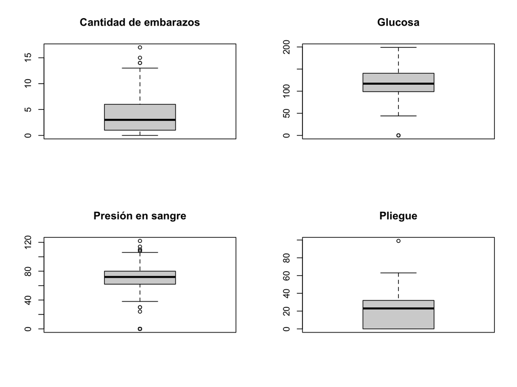

```r
par(mfrow = c(2, 2))

#Boxplot para Pregnancies
boxplot(diabetes$Pregnancies, main = "Cantidad de embarazos")
#Boxplot para Glucose
boxplot(diabetes$Glucose, main = "Glucosa")
#Boxplot para BloodPressure
boxplot(diabetes$BloodPressure, main = "Presión en sangre")
#Boxplot para SkinThickness
boxplot(diabetes$SkinThickness, main = "Pliegue")
```

Con ayuda de los gráficos podemos observar que en la base de datos la mayoría de mujeres ha tenido entre 1 y 5 embarazos, con una media de 3 aproximadamente, aunque hay mujeres que han tenido más de 10 embarazos.

Con la glucosa se ve un gráfico de caja y bigote muy distribuido homogeneamente con un único dato atípico el cual podría ser un error en la digitación. Los valores de Glucosa van desde 50 hasta 200.

Para la presión en sangre se observa que los datos estan muy agrupados entre 40 y 100 aunque se observan 6 datos atípicos que exceden estos límites.

Para el Pliegue, podemos ver que el tamaño de los pliegues estan mú agrupador entre 0 y 40 con una media de 20. Aunque se observa un solo dato atipico de aproximadamente 100. este dato podría ser algun error de digitación de datos o de mala medición.

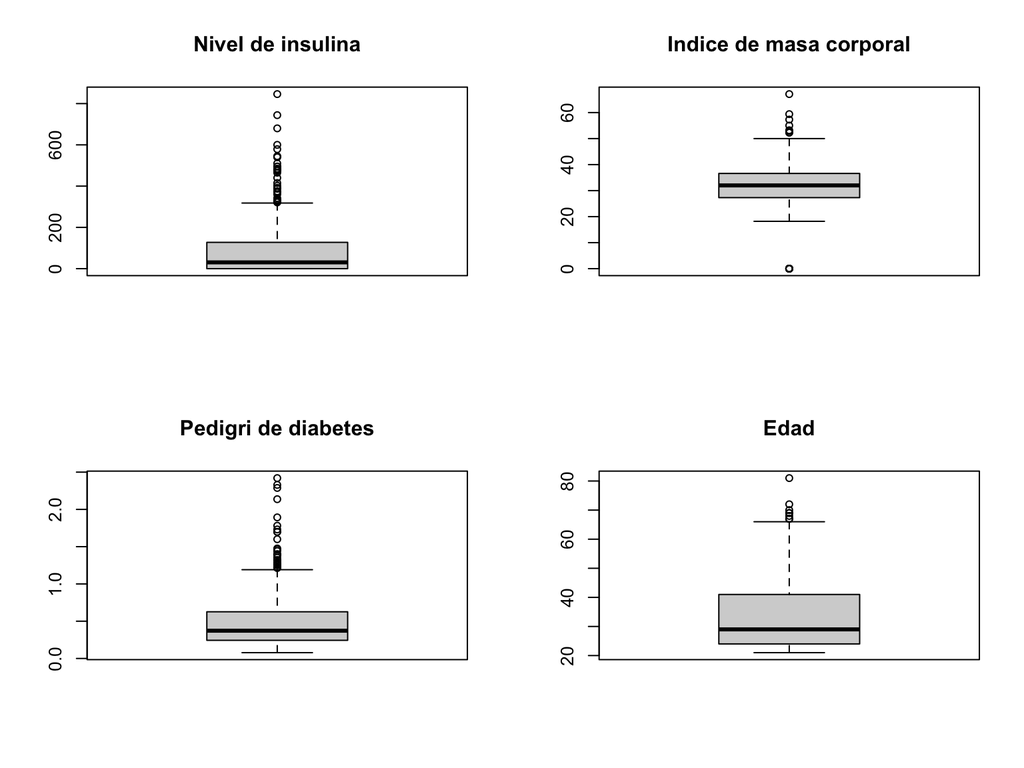

```r
par(mfrow = c(2, 2))
#Boxplot para Insulin
boxplot(diabetes$Insulin, main = "Nivel de insulina")
#Boxplot para BMI
boxplot(diabetes$BMI, main = "Indice de masa corporal")
#Boxplot para DiabetesPedigreeFunction
boxplot(diabetes$DiabetesPedigreeFunction, main = "Pedigri de diabetes")
#Boxplot para Age
boxplot(diabetes$Age, main = "Edad")
```

```r
par(mfrow = c(1, 1))
```

Para el indice de masa corporal se puede observar que están bastante bien agrupados entre 20 y 50 con una media de 30. Se observan solo unos cuantos valores atípicos para esta variable.

Para el pedigri de diabetes que es una función que considera los antecedentes familiares para calcular un factor de riesgo de desarrollar diabetes. En nuestra base de datos la mayoría tienen un factor de riesgo entre 0 y 1 con un promedio poco debajo de 0.5. Se pueden ver múltiples datos atipicos con factor de riesgo que en ocasiones supera 2.0.

Para la edad tenemos una población bastante joven con una media de 30 años aunque hay mujeres mayores a los 70.

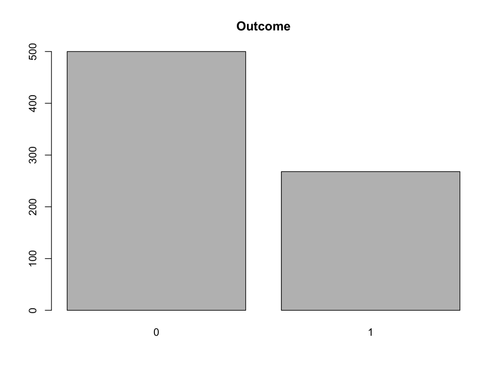

```r
barplot(table(diabetes$Outcome), main='Outcome')
```

La variable `Outcome` nos dice si la persona desarrollo o no diabetes. Siendo 0 que no la desarrollo y 1 que si. Podemos observar que tenemos casi el doble de pacientes que no desarrollaron la enfermedad siendo estos 500 aproximadamente y dejando al resto (250 aproximadamente) como pacientes que si desarrollaron la enfermedad.

## En este conjunto de datos hay datos faltantes ¿Cuántos valores faltantes hay para cada variable?

```r
colSums(is.na(diabetes))
```

```
##              Pregnancies                  Glucose            BloodPressure
##                        0                        0                        0
##            SkinThickness                  Insulin                      BMI
##                        0                        0                        0
## DiabetesPedigreeFunction                      Age                  Outcome
##                        0                        0                        0
```

Podemos confirmar lo visto en el resumen general de la base de datos que todos los datos están completos y que no hay ningún `NA` en la base de datos.

## Diagrama bivariante (Glucosa ~ Insulina).

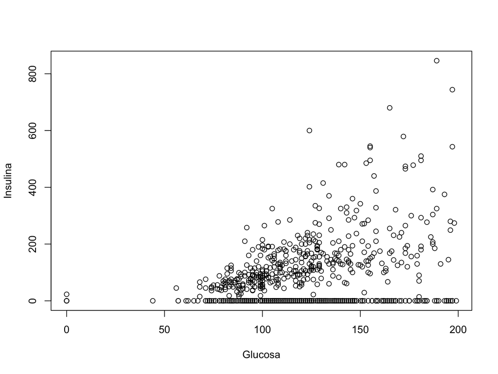

```r
plot(diabetes$Glucose, diabetes$Insulin, xlab = "Glucosa", ylab = "Insulina")
```

En el gráfico anterior se puede ver que hay una tendencia líneal entre estas dos variables. Pero se ve una fila de puntos de cero en la Insulina. Esto puede significar que de estas mujeres no se tomaron medidas de insulina, contemos en cuantos registros la insulina es 0.

```r
nrow(diabetes[diabetes$Insulin == 0, ])
```

```
## [1] 374
```

Existen 374 registros con niveles de insulina igual a 0. Para esto podríamos suponer que de estas personas no se les hizo el test de 2 horas de la insulina.

Volvamos a graficar `Glucosa ~ Insulina` sin los registros que tienen 0 en `Insulina`.

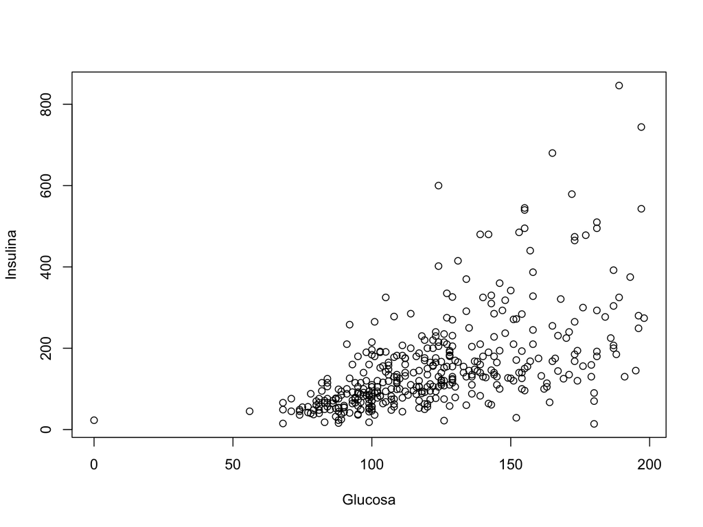

```r
diabetes_filtrado = diabetes[diabetes$Insulin != 0, ]
plot(diabetes_filtrado$Glucose, diabetes_filtrado$Insulin, xlab = "Glucosa", ylab = "Insulina")
```

Aho se ve con mejor claridad una posible relación. Aunque entre más glucosa se encuentra, la variacion en la insulina aumenta.

## Tablas de frecuencias relativas y absolutas de “Outcome” (presencia de la enfermedad)

```r
table(diabetes$Outcome)
```

```
##
##   0   1
## 500 268
```

```r
prop.table(table(diabetes$Outcome))
```

```
##
##         0         1
## 0.6510417 0.3489583
```

Como se sospechaba en la gráfica de barras de `Outcome` presentada previamente, se encuentran 500 (65%) registros de personas sin diabetes y 268 (35%) con la enfermedad.

Debido a que se detecto previamente el problema con la `Glucosa ~ Insulina`, quisiera saber cuantas de estas personas con Insulina = 0 son personas con la enfermedad y cuantas sin ellas.

**En las siguientes tablas de frecuencias, la fila TRUE hace referencias a aquellas que tienen la Insulina = 0**

```r
table(diabetes$Insulin == 0, diabetes$Outcome)
```

```
##
##           0   1
##   FALSE 264 130
##   TRUE  236 138
```

```r
prop.table(table(diabetes$Insulin == 0, diabetes$Outcome))
```

```
##
##                 0         1
##   FALSE 0.3437500 0.1692708
##   TRUE  0.3072917 0.1796875
```

Con esta información podemos ver que la distribución de pacientes en la base de datos que no tienen una medida de Insulina están distribuidas homogeneamente. Podríamos considerar en remover estos casos y tomarlos como datos faltantes para que nuestros análisis sean más exactos.

Asi como la insulina presenta *ceros*, en el diagrama de caja y bigote de pliegue de piel se ve la existencia de ceros. Por fines exploratorios veremos a cuantos pacientes tienen esta medida igual a 0 y como se distribuyen con la variable Outcome.

**En las siguientes tablas de frecuencias, la fila TRUE hace referencias a aquellas que tienen el tamaño del Pliegue = 0**

```r
table(diabetes$SkinThickness == 0, diabetes$Outcome)
```

```
##
##           0   1
##   FALSE 361 180
##   TRUE  139  88
```

```r
prop.table(table(diabetes$SkinThickness == 0, diabetes$Outcome))
```

```
##
##                 0         1
##   FALSE 0.4700521 0.2343750
##   TRUE  0.1809896 0.1145833
```

Podemos observar que son menos los registros a los que les falta la medicion de pliegue comparado con los de insulina.

Como parte final, vere en que proporción los registros no tienen alguna de las dos variables con valor 0.

**En las siguientes tablas de frecuencias, la fila TRUE hace referencias a aquellas que tienen la Insulina = 0 o el Pliegue = 0**

```r
table(diabetes$SkinThickness == 0 | diabetes$Insulin == 0, diabetes$Outcome)
```

```
##
##           0   1
##   FALSE 264 130
##   TRUE  236 138
```

```r
prop.table(table(diabetes$SkinThickness == 0 | diabetes$Insulin == 0, diabetes$Outcome))
```

```
##
##                 0         1
##   FALSE 0.3437500 0.1692708
##   TRUE  0.3072917 0.1796875
```

Se puede ver que esta tabla es identica a la que se hizo de los registros que tenian Insulina = 0. Será de mucha importancia remover estos datos ya que podríamos considerarlos como registros con datos faltantes.

Veamos como se distribuyen ahora estas dos variables sin tomar en cuenta los registros que tienen 0 en la medida de insulina y de pliegue.

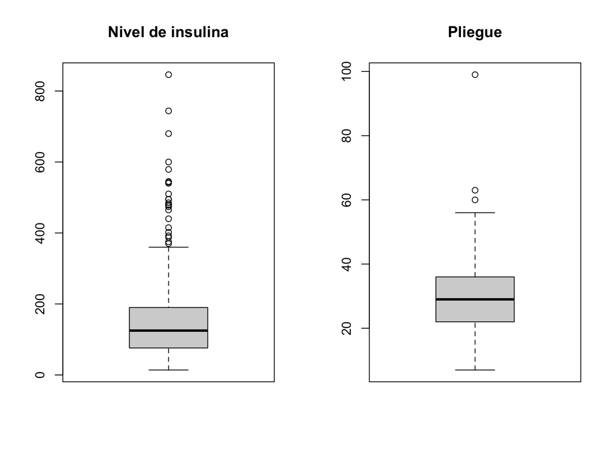

```r
par(mfrow = c(1, 2))
#Boxplot para Insulin
boxplot(diabetes[diabetes$Insulin != 0, 'Insulin'], main = "Nivel de insulina")
#Boxplot para SkinThickness
boxplot(diabetes[diabetes$SkinThickness != 0, 'SkinThickness'], main = "Pliegue")
```

Se puede ver que para la caja de nivel de insulina, ahora los datos ya no estan bastante agrupados en cero, aunque se siguen encontrando datos atípicos donde el nivel de insulina es superior a 375.

Para el Pliegue se puede ver que se tiene una mejor distribucion. Ahora ya no se tienen los datos agrupados cerca del 0, aunque ahora se detectaron 2 datos atípico más que cuando no se consideraba el filtro a los datos.

Estas observaciones anteriores son de importancia debido a que se estaban considerando los valores 0 como valores reales, cuando realmente podrían ser datos faltantes los cuales afectarian negativamente nuestros analisis de correlación o de regresión.

## Limpieza de Datos

Existen varios registro con `0` en variables donde un 0 no tiene sentido. Por ejemplo en la variable Glucosa, Presion Sanguinea, Pliegue, Nivel de Insulina e Indice de masa coporal. Para seguir con nuestros analisis es importante considerar que estos *ceros* realmente son datos faltantes y filtrarlos.

```r
diabetes_filtrado = diabetes %>%
    filter(
        Glucose != 0,
        BloodPressure != 0,
        SkinThickness != 0,
        Insulin != 0,
        BMI != 0
    )

# Cantidad de registros de la base de datos filtrada
nrow(diabetes_filtrado)
```

```
## [1] 392
```

```r
# Representatividad de personas con diabetes y sin ella
table(diabetes_filtrado$Outcome)
```

```
##
##   0   1
## 262 130
```

```r
prop.table(table(diabetes_filtrado$Outcome))
```

```
##
##         0         1
## 0.6683673 0.3316327
```

Aplicando la limpieza de datos nos hemos quedado con 392 registros y en la tabla anterior podemos observar que la distribución porcentual de pacientes con diabetes y sin la enfermedad es similar a la original.

# 5) (1,5 puntos) Complementando el apartado anterior, elaborar un análisis de regresión de dos conjuntos de variables (LAB2). La elección de las variables, los resultados, así como su relación deben de estar correctamente justificada.

Calculamos la matriz de correlación del conjunto de datos y la representación gráfica que muestre la relación de todas las variables.

```r
corr = cor(diabetes_filtrado)
print(corr)
```

```
##                           Pregnancies   Glucose BloodPressure SkinThickness
## Pregnancies               1.000000000 0.1982910     0.2133548     0.0932094
## Glucose                   0.198291043 1.0000000     0.2100266     0.1988558
## BloodPressure             0.213354775 0.2100266     1.0000000     0.2325712
## SkinThickness             0.093209397 0.1988558     0.2325712     1.0000000
## Insulin                   0.078983625 0.5812230     0.0985115     0.1821991
## BMI                      -0.025347276 0.2095159     0.3044034     0.6643549
## DiabetesPedigreeFunction  0.007562116 0.1401802    -0.0159711     0.1604985
## Age                       0.679608470 0.3436415     0.3000389     0.1677611
## Outcome                   0.256565956 0.5157027     0.1926733     0.2559357
##                             Insulin         BMI DiabetesPedigreeFunction
## Pregnancies              0.07898363 -0.02534728              0.007562116
## Glucose                  0.58122301  0.20951592              0.140180180
## BloodPressure            0.09851150  0.30440337             -0.015971104
## SkinThickness            0.18219906  0.66435487              0.160498526
## Insulin                  1.00000000  0.22639652              0.135905781
## BMI                      0.22639652  1.00000000              0.158771043
## DiabetesPedigreeFunction 0.13590578  0.15877104              1.000000000
## Age                      0.21708199  0.06981380              0.085029106
## Outcome                  0.30142922  0.27011841              0.209329511
##                                 Age   Outcome
## Pregnancies              0.67960847 0.2565660
## Glucose                  0.34364150 0.5157027
## BloodPressure            0.30003895 0.1926733
## SkinThickness            0.16776114 0.2559357
## Insulin                  0.21708199 0.3014292
## BMI                      0.06981380 0.2701184
## DiabetesPedigreeFunction 0.08502911 0.2093295
## Age                      1.00000000 0.3508038
## Outcome                  0.35080380 1.0000000
```

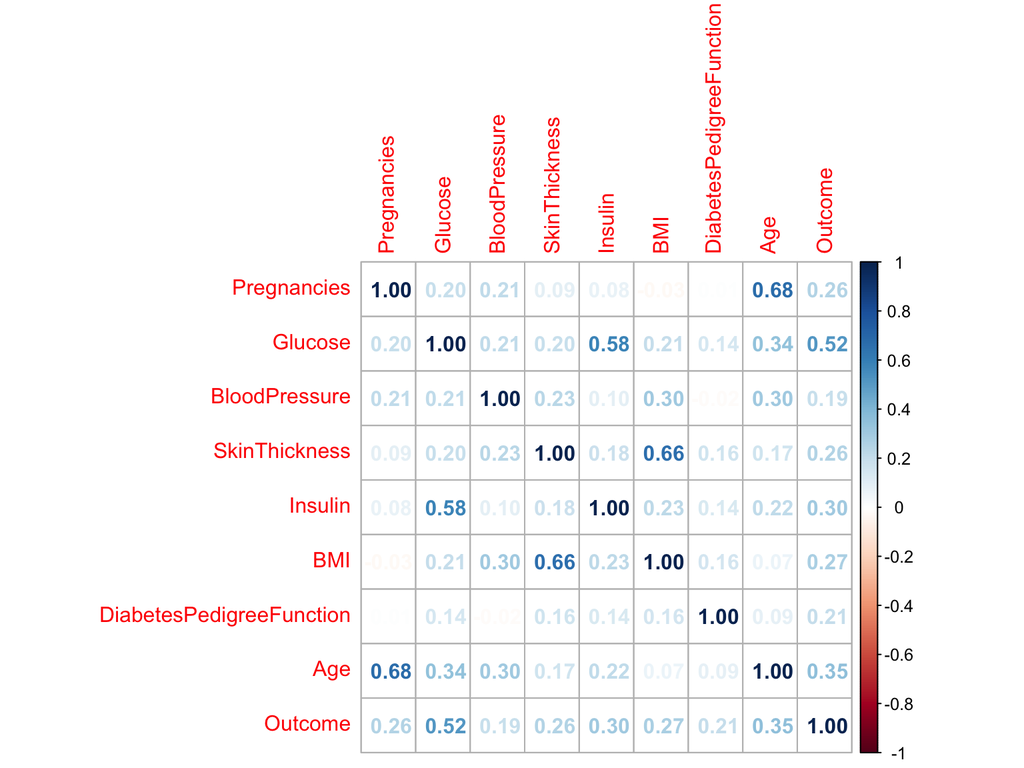

```r
library(corrplot)
corrplot(corr,method = "number")
```

## Glucosa ~ Edad + IMC

```r
model = lm(Glucose ~ Age + BMI, data = diabetes_filtrado)
summary(model)
```

```
##
## Call:
## lm(formula = Glucose ~ Age + BMI, data = diabetes_filtrado)
##
## Residuals:
##     Min      1Q  Median      3Q     Max
## -72.743 -19.207  -3.631  18.212  83.122
##
## Coefficients:
##             Estimate Std. Error t value Pr(>|t|)
## (Intercept)  64.6675     7.9508   8.133 5.66e-15 ***
## Age           1.0003     0.1415   7.067 7.37e-12 ***
## BMI           0.8187     0.2055   3.985 8.06e-05 ***
## ---
## Signif. codes:  0 '***' 0.001 '**' 0.01 '*' 0.05 '.' 0.1 ' ' 1
##
## Residual standard error: 28.48 on 389 degrees of freedom
## Multiple R-squared:  0.1527, Adjusted R-squared:  0.1483
## F-statistic: 35.05 on 2 and 389 DF,  p-value: 1.013e-14
```

En este modelo de regresión lineal se está intentando predecir el nivel de Glucosa en sangre en función de la edad y el índice de masa corporal (BMI) de los pacientes. Los resultados indican que existe una relación estadísticamente significativa entre estas variables (p-valor < 0.05). El coeficiente de Age es 1.0003, lo que significa que a medida que la edad de un paciente aumenta en 1 unidad, se espera que su nivel de Glucosa aumente en 1.0003 unidades. El coeficiente de BMI es 0.8187, lo que significa que a medida que el BMI de un paciente aumenta en 1 unidad, se espera que su nivel de Glucosa aumente en 0.8187 unidades. El R cuadrado es 0.1527, lo que significa que estas dos variables explican el 15.27% de la variación en el nivel de Glucosa. Sin embargo, este modelo es solo una aproximación y es importante tener en cuenta otros factores que pueden influir en el nivel de Glucosa.

## Glucosa ~ Presion Sanguinea + Insulina + Edad + Diabetes

Este segundo modelo lo realizaremos meramente por enfoque estádistica de obtener un modelo con un mejor $R^2$. En este modelo tomaremos en cuenta los niveles de insulina y si el paciente tiene diabetes para medir los niveles de glucosa, lo cual es bastante trivial. Pero con el objetivo de obtener un mejor modelo las tomaremos en cuenta.

```r
model2 = lm(Glucose ~ BloodPressure + Insulin + Age + Outcome, data = diabetes_filtrado)
summary(model2)
```

```
##
## Call:
## lm(formula = Glucose ~ BloodPressure + Insulin + Age + Outcome,
##     data = diabetes_filtrado)
##
## Residuals:
##     Min      1Q  Median      3Q     Max
## -72.983 -13.791  -2.279  12.581  77.958
##
## Coefficients:
##               Estimate Std. Error t value Pr(>|t|)
## (Intercept)   74.83320    6.78194  11.034  < 2e-16 ***
## BloodPressure  0.17152    0.09501   1.805  0.07180 .
## Insulin        0.11732    0.01002  11.703  < 2e-16 ***
## Age            0.33217    0.12280   2.705  0.00713 **
## Outcome       21.44803    2.64549   8.107 6.88e-15 ***
## ---
## Signif. codes:  0 '***' 0.001 '**' 0.01 '*' 0.05 '.' 0.1 ' ' 1
##
## Residual standard error: 22.29 on 387 degrees of freedom
## Multiple R-squared:  0.4839, Adjusted R-squared:  0.4785
## F-statistic:  90.7 on 4 and 387 DF,  p-value: < 2.2e-16
```

# 6) (1 punto) Realizar, a partir de los conceptos trabajados en el LAB4 y la PEC2, un estudio probabilístico (a elección propia) de al menos 3 de las variables, que ayude a esclarecer cuestiones de relevancia que se plantean en los ámbitos de acción estudiados.

## Niveles de glucosa

Utilizaremos los niveles de Glucosa para este inciso y asumiremos que sigue una distribución normal debido a que tenemos más de 50 registros y podemos aplicar el teorema del limite central.

En este dataset para la obtencion de los niveles de glucosa se hizo una prueba de tolerancia.

En esta prueba los valores de glucosa menores 140 se consideran normales, de 140 a 199 se consideran prediabetico y mayores a 200 indica que se tiene diabetes.

https://www.cdc.gov/diabetes/spanish/basics/getting-tested.html

### Distribución de los datos

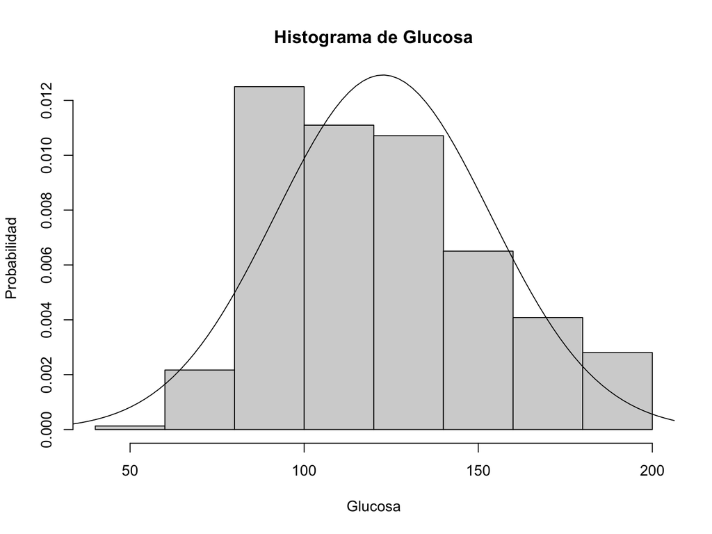

```r
mu = mean(diabetes_filtrado$Glucose)
s = sd(diabetes_filtrado$Glucose)
hist(diabetes_filtrado$Glucose, prob = TRUE, xlab='Glucosa', ylab='Probabilidad', main='Histograma de Glucosa')
curve(dnorm(x, mean = mu, sd = s), from = min(diabetes_filtrado$Glucose) - 30, to = max(diabetes_filtrado$Glucose) + 30, add = TRUE)
```

### ¿Cuál es la probabilidad de que un individuo tenga la glucosa por debajo de 140?

```r
pnorm(140, mean = mu , sd = s)
```

```
## [1] 0.7132586
```

En esta población existe un 71% de probabilidad de tener los niveles de glucosa en un rango normal (menor a 40)

### ¿Cuál es la probabilidad de que un individuo tenga la glucosa entre 140 - 199?

```r
p140 = pnorm(140, mean = mu , sd = s)
p199 = pnorm(199, mean = mu , sd = s)
p199 - p140
```

```
## [1] 0.2800748
```

La probabilidad de tener los niveles de glucosa en un rango prediabetico es del 28 %.

### ¿Cuál es la probabilidad de que una persona tenga la glucosa por encima de 200?

```r
pnorm(200, mean = mu , sd = s, lower.tail = FALSE)
```

```
## [1] 0.00608554
```

La probabilidad de tener los niveles de glucosa por encima de 200 y considerarse diabetico es del 0.6%. Parece curioso ya que es una probabilidad muy baja. Es importante mencionar que este es un analisis hipotético y que podría alejarse de la realidad.

## Probabilidad de ser diabetico

Se modelara la población del dataset como un evento binomial donde la probabilidad de tener diabetes es de:

```r
p = nrow(diabetes_filtrado[diabetes_filtrado$Outcome == 1, ])/nrow(diabetes_filtrado)
p
```

```
## [1] 0.3316327
```

Con esta probabilidad nos plantearemos de que tomaremos una muesta de 10 individuos y queremos contestar a las siguientes interrogantes.

### ¿Cuál es la probabilidad de que todas las personas tengan diabetes?

```r
N = 10
p_todos = dbinom(N, N, p)
p_todos
```

```
## [1] 1.609062e-05
```

### ¿Cuál es la probabilidad de que ninguna persona tenga diabetes?

```r
p_ninguno = dbinom(0, N, p)
p_ninguno
```

```
## [1] 0.01778903
```

### ¿Cuál es la probabilidad de que la mitad de las personas tenga diabetes?

```r
p_mitad = dbinom(N/2, N, p)
p_mitad
```

```
## [1] 0.1348227
```

### ¿Cuál es la probabilidad de que almenos 5 personas no tengan diabetes?

```r
p_5 = pbinom(5, N, p)
p_5
```

```
## [1] 0.9251651
```

# 7) (1,5 puntos) Complementando el apartado anterior, elaborar un análisis ANOVA de dos conjuntos de variables (LAB5). La elección de las variables, los resultados, así como su relación deben de estar correctamente justificada. Además, realizar una prueba clúster de las variables, y si existe un fuerte agrupamiento, elaborar un dendograma (LAB5).

## ANOVA

Utilizaré las variables del apartado 5 para realizar el análisis ANOVA ya que son las mas prometedoras de las que tienen un sentido lógico e interpretable.

```r
model = aov(Glucose ~ Age + BMI, data = diabetes_filtrado)
summary(model)
```

```
##              Df Sum Sq Mean Sq F value   Pr(>F)
## Age           1  43975   43975   54.21 1.08e-12 ***
## BMI           1  12880   12880   15.88 8.06e-05 ***
## Residuals   389 315529     811
## ---
## Signif. codes:  0 '***' 0.001 '**' 0.01 '*' 0.05 '.' 0.1 ' ' 1
```

Los resultados del ANOVA muestran que tanto la edad como el índice de masa corporal (BMI) tienen un efecto significativo en la variable dependiente (en este caso, GLucose). Esto se deduce de los valores p muy pequeños y de los asteriscos junto a las variables “Age” y “BMI” en la columna “Pr(>F)”.

El valor F en sí mismo también es significativo, lo que indica que hay una diferencia significativa entre los promedios de la variable dependiente para los diferentes grupos de edad y BMI.

## Clustering

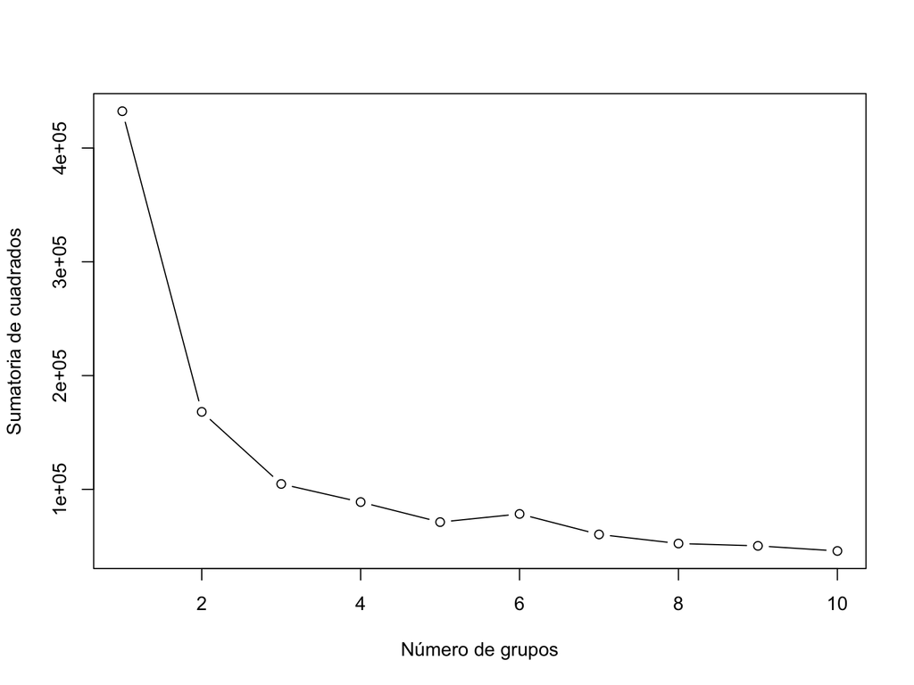

```r
cluster = diabetes_filtrado[,c('Glucose', 'Age', 'BMI')]
wss <- (nrow(cluster[,c()])-1)*sum(apply(cluster[,1:ncol(cluster)],2,var))

for (i in 2:10)
  wss[i] <- sum(kmeans(cluster[,1:ncol(cluster)], centers=i)$withinss)

plot(1:10, wss, type="b", xlab="Número de grupos",  ylab="Sumatoria de cuadrados")
```

En el gráfico anterior podemos ver que apartir de los 5 grúpos la diferencia de cuadrados cambia demasiado poco al aumentar la cantidad de grupos asi que agruparemos los datos en 5 grupos distintos.

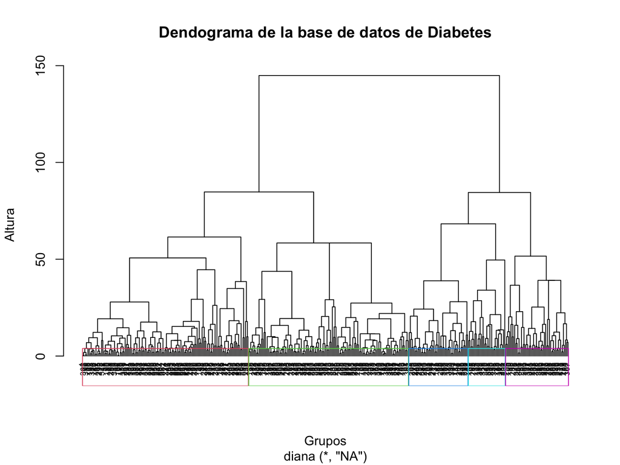

```r
hc_div<-diana(diabetes_filtrado[,c('Glucose', 'Age', 'BMI')]) ##calculamos los clústeres jerárquicos
pltree(hc_div,hang=-1,cex=0.6, main = "Dendograma de la base de datos de Diabetes", ylab = 'Altura', xlab = 'Grupos')
rect.hclust(hc_div,k=5,border=2:10)
```

```r
hc_div$dc ##calculamos el coeficiente de división
```

```
## [1] 0.9667834
```

Podemos visualizar los 5 grupos generados en el dendograma con un coeficiente de división muy cercano a 1. En este dendograma podemos observar que las primeras dos niveles estan separados entre si. El del lado izquierdo lo divide en los dos grupos más grandes y el de la derecha en tres grupos más pequeños.

# 8) (1 punto) A partir de los datos de origen y el estudio realizado (incluyendo todos los puntos anteriores), presentar un apartado de conclusiones. Esta sección debe incluir un resumen de los principales resultados obtenidos en apartados anteriores, que ayuden al lector a comprender el ámbito de estudio. Además, se valorará positivamente la coherencia de resultados y las justificaciones presentadas.